# [EM1415] - Predictive Business and Finance

The Tourism Forecasting 2010 Competition (JIF)

Crapanzano Edoardo – 889685

2026-09-23

# 1 Introduction

Tourism is one of the most rapidly growing global industries and tourism forecasting is becoming an increasingly important activity in planning and managing the industry. The 2010 tourism forecasting competition had two parts. In part I, competitors were tasked with producing forecasts for the next four years, given 518 series of annual tourism data. The data consists of 518 annual series, each related to some (undisclosed) tourism activity. Tourism activities include inbound tourism numbers to one country from another country, visitor nights in a particular country, tourism expenditure, etc. The series differ in length, ranging from 7-year series to 43-year series. They also differ in the order of magnitude of values. The data is available at www.kaggle.com/c/tourism1/Data. While the competition goal was to achieve the highest predictive accuracy, the goal of this case is to highlight different aspects of the forecasting process that pertain to forecasting a large number of series.

## 1.1 Uploading Data

```r
tourism_data = read.csv("tourism_data.csv")
```

The packages used to create the codes are the following:

```r
if (!require("tidyverse")) install.packages("tidyverse") # Collection of data science packages
if (!require("fpp3")) install.packages("fpp3")
if (!require("visdat")) install.packages("visdat")

library(tidyverse)
library(fpp3)
library(visdat)
library(readr)
library(dplyr)          # Data manipulation with verbs
library(ggplot2)        # Create elegant data visualizations
library(tidyr)          # Tidy and reshape data
```

# 2 Exercise 1

We need to create the ‘Tsibble’ object (Annual Time Series) and transform the data because they are in wide format (columns from Y1 to Y518). Thus, we need long format for fpp3. We also preserve the time alignment by adding a Time index before pivoting.

```r
tourism_ts = tourism_data %>%
  mutate(Time = row_number()) %>%
  pivot_longer(cols = starts_with("Y"), names_to = "Series", values_to = "Value") %>%
  filter(!is.na(Value)) %>% # Removing NA values so that the data is clean and ready for the analysis
  as_tsibble(index = Time, key = Series) # Convert to a tsibble (time series tibble)

glimpse(tourism_ts)
```

```
## Rows: 10,606
## Columns: 3
## Key: Series [518]
## $ Time   <int> 33, 34, 35, 36, 37, 38, 39, 40, 41, 42, 43, 18, 19, 20, 21, 22,…
## $ Series <chr> "Y1", "Y1", "Y1", "Y1", "Y1", "Y1", "Y1", "Y1", "Y1", "Y1", "Y1…
## $ Value  <dbl> 25092.23, 24271.51, 25828.99, 27697.50, 27956.23, 29924.43, 302…
```

Based on the dataset of `tourism_data`, we can investigate the distribution of all the different Time Series or a random subset of them.

**Advanced Visualization**: plotting 518 series on one legend is messy. So we can create a “Spaghetti Plot” by hiding the legend and using transparency, guaranteeing a clearer view.

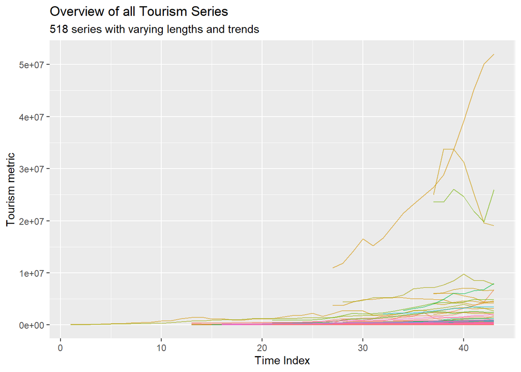

```r
tourism_ts %>%
  autoplot(Value, alpha = 0.6) +
  theme(legend.position = "none") +
  labs(title = "Overview of all Tourism Series", subtitle = "518 series with varying lengths and trends", y = "Tourism metric", x = "Time Index")
```

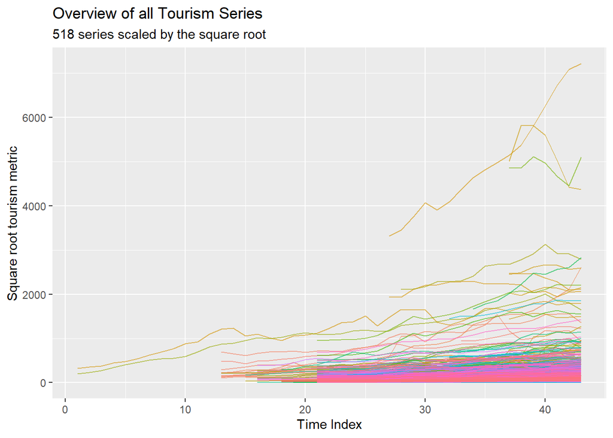

```r
tourism_ts %>%
  autoplot(sqrt(Value), alpha = 0.6) +
  theme(legend.position = "none") +
  labs(title = "Overview of all Tourism Series", subtitle = "518 series scaled by the square root", y = "Square root tourism metric", x = "Time Index")
```

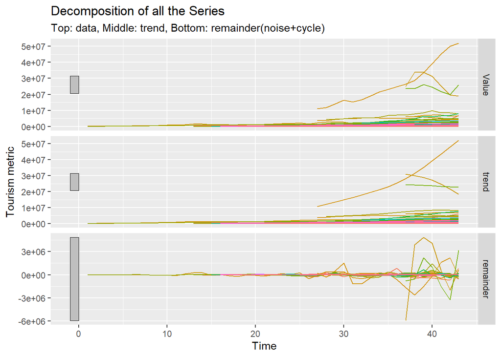

```r
tourism_ts %>%
  model(STL(Value)) %>%
  components()%>%
  autoplot() +
  theme(legend.position = "none") +
  labs(title = "Decomposition of all the Series", subtitle = "Top: data, Middle: trend, Bottom: remainder(noise+cycle)", y = "Tourism metric")
```

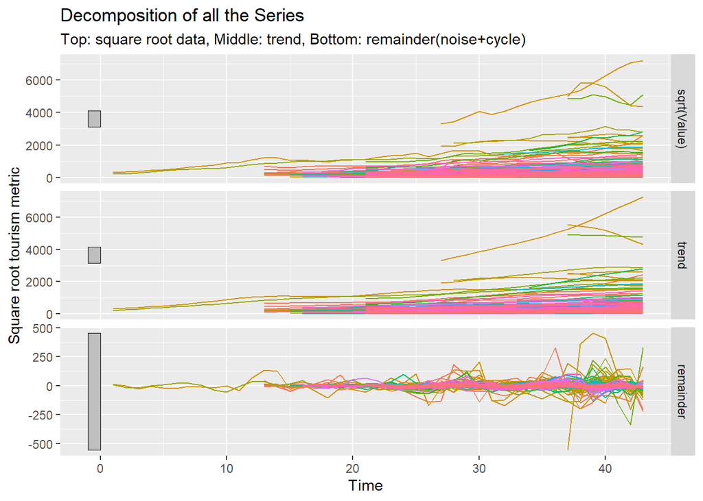

```r
tourism_ts %>%
  model(STL(sqrt(Value))) %>%
  components()%>%
  autoplot() +
  theme(legend.position = "none") +
  labs(title = "Decomposition of all the Series", subtitle = "Top: square root data, Middle: trend, Bottom: remainder(noise+cycle)", y = "Square root tourism metric")
```

The series have different starting points and they differ significantly in length and in magnitude (tourism activities with different scales). Type of components that are visible:  
- *Trend*: this is the most dominant component across the series and the plot reveals that most series exhibit strong trends over time. Indeed, the tourism numbers follow economic expansion, leading to long-term upward (or occasionally downward) slopes;  
- *Remainder*: random fluctuations are present but do not obscure the underlying trends in the majority of the larger series.

The *cyclical component* is not clearly visible since the remaining residuals resemble irregular noise rather than a smooth, wave-like cyclical pattern. With many series being very short (e.g., 7 to 15 years), it is extremely difficult to statistically separate a multi-year cycle from the trend or random noise.  
Clear *seasonal patterns* are difficult to distinguish from the trend for every series. The data represents annual figures, where seasonality is not applicable because it is impossible to see intra-year patterns such us quarterly, monthly or weekly patterns.

**Detailed Visualization**: Facet Plot of a random subset of series to see components clearly, we plot a random sample of 12 series.

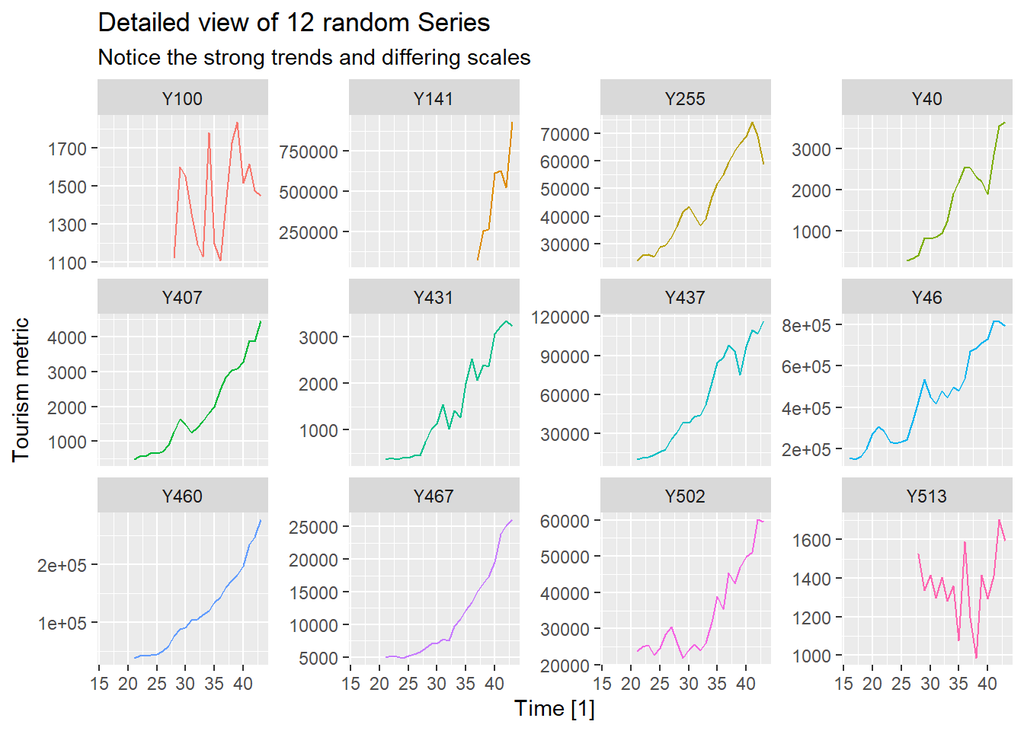

```r
set.seed(987)
sample_series = sample(unique(tourism_ts$Series), 12)

tourism_ts %>%
  filter(Series %in% sample_series) %>%
  autoplot(Value) +
  facet_wrap(~Series, scales = "free_y") +
  theme(legend.position = "none") +
  labs(title = "Detailed view of 12 random Series", subtitle = "Notice the strong trends and differing scales", y = "Tourism metric")
```

To investigate if the cyclical component is visible or not, we will use LOESS smoother (STL decomposition) which separates the Trend, Seasonality, and Remainder (Noise/Cycle). Since the data is annual (frequency = 1), standard seasonal decomposition doesn’t apply automatically, so we use a local regression (LOESS) to separate the Trend from the Remainder. If the “Remainder” looks random, there is no cycle. If it looks like a wave, there is a cycle.

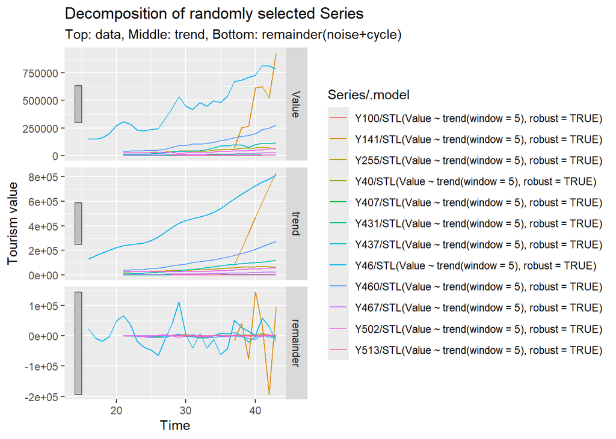

```r
dcmp = tourism_ts %>%
  filter(Series %in% sample_series)%>%
  model(STL(Value ~ trend(window = 5), robust = TRUE)) %>% # trend controls wiggliness of trend component
  components()

dcmp %>%
  autoplot() +
  labs(title = "Decomposition of randomly selected Series", subtitle = "Top: data, Middle: trend, Bottom: remainder(noise+cycle)", y = "Tourism value")
```

Since most of the series are short, decomposition algorithms tend to absorb any long-term movement into the trend component. We have applied a small window (e.g., window = 5) so that the model only looks at 5 time steps in order to react quickly to changes and bend to follow the data more closely. When we mathematically remove the trend (detrending), the remaining “residuals” mostly resemble irregular noise rather than a smooth, wave-like cyclical pattern. Most series exhibit a strong, monotonic upward: this overpowering movement makes it difficult to see the “business cycle” (the rise and fall of tourism demand due to economic conditions for non-fixed period of at least 2 years). Thus, the cyclical component is not clearly visible.

Then, we need to check for internal missing values through `scan_gaps()` that searches if there are missing time steps within the series range.

```r
#Missing values
gaps = scan_gaps(tourism_ts)

if(nrow(gaps) > 0) {
  print("Warning: Internal missing values found!")
  print(gaps)
} else {
  print("Check passed: No internal missing values found.")
}
```

```
## [1] "Check passed: No internal missing values found."
```

```r
#Zero values
total_zeros = sum(tourism_data == 0, na.rm = TRUE)

if (total_zeros > 0) {
  print(paste("ALERT: Found", total_zeros, "zero values."))
} else {
  print("Clean: No zero values found in the dataset.")
}
```

```
## [1] "Clean: No zero values found in the dataset."
```

```r
#Negative values
total_negatives = sum(tourism_data < 0, na.rm = TRUE)

if (total_negatives > 0) {
  print(paste("ALERT: Found", total_negatives, "negative values."))
} else {
  print("Clean: No negative values found.")
}
```

```
## [1] "Clean: No negative values found."
```

There are no internal missing values (gaps in the middle of a series). The NA values observed in the dataset are solely due to the differing lengths and starting points of the series. There are no zero values and no negative values, which is consistent with tourism flow data. The data appears clean, though the short duration of some series (e.g., 7 points/years) limits the complexity of models that can be fitted to them.

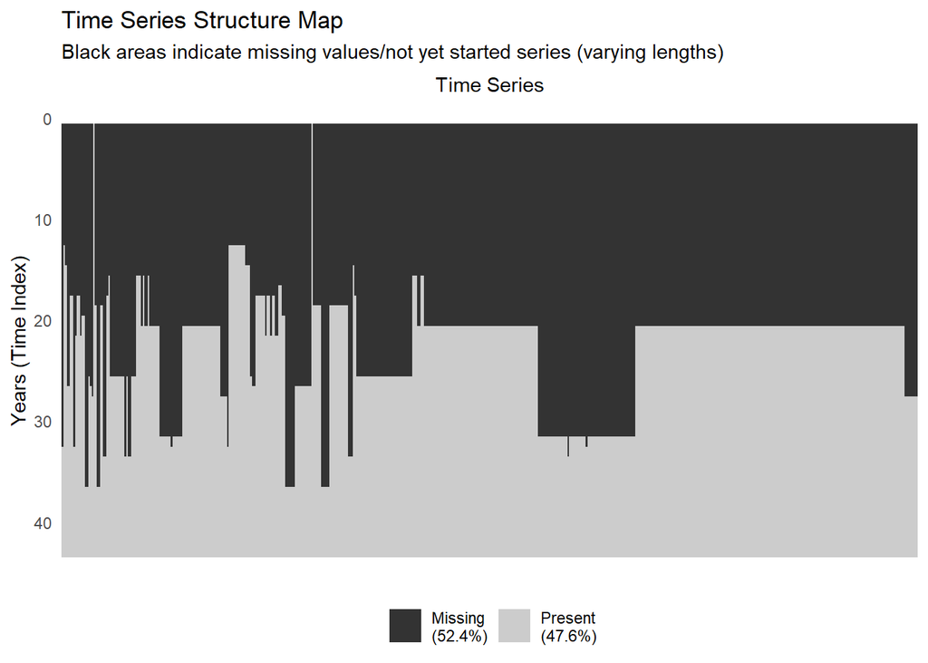

```r
vis_miss(tourism_data) +
  labs(title = "Time Series Structure Map",
       subtitle = "Black areas indicate missing values/not yet started series (varying lengths)",
       x = 'Time Series', y = "Years (Time Index)")+
  theme_minimal() +
  theme(axis.text.x = element_blank(), panel.grid = element_blank(), legend.position = "bottom")
```

This plot clearly shows the “stepped” structure of the dataset: black areas indicate years where the series had not started yet. It does not mean that tourism was zero in those years; it simply means the data was not recorded.

# 3 Exercise 2

```r
# Create Training Set (Remove the last 4 years)
n_years = nrow(tourism_data)
train_set = tourism_data[1:(n_years - 4), ]

# Create Validation Set (Keep only the last 4 years)
validation_set = tourism_data[(n_years - 3):n_years, ]

# Verify the split
cat("Training Years:", nrow(train_set), "\n") # Should be 39
```

```
## Training Years: 39
```

```r
cat("Validation Years:", nrow(validation_set), "\n") # Should be 4
```

```
## Validation Years: 4
```

```r
#alternative solution using the cleaned dataset in the long format
train_tourism_ts = tourism_ts%>% #training set
  filter(Time <= max(Time) - 4)

test_tourism_ts = tourism_ts%>% #test set
  filter(Time > max(Time) - 4)
```

The logic is *Out-of-Sample Evaluation*: when forecasting, we are always standing in the present trying to predict the unknown future. By hiding the last 4 years from the model during training, we simulate this reality by asking the model: “If you were standing 4 years ago, could you have accurately predicted what actually happened?”  
For yearly data, a 4-year horizon represents a medium-term forecast. This partition specifically tests if our model captures the underlying trend stability rather than just short-term noise.

The main disadvantage is Information Loss, which is particularly acute with yearly data:  
-the most valuable data for forecasting next year is usually this year’s data. By cutting off the last 4 years, we are forcing the model to forecast based on data that is already 4 years old. If a major structural change (e.g., a new travel policy or economic shift) occurred in the last 3 years, the model will be completely unaware of it and likely produce poor forecasts.  
-In our dataset `tourism_data` we have time series of different length; removing 4 observations is disproportionately harmful to shorter series. For a series with only 7 observations, this approach leaves only 3 data points for training (a 57% data loss), rendering statistical estimation of trends or parameters extremely unstable. In time series analysis, every data point counts; reducing the training data to a range of 39-3 observations might make it harder for the model to statistically distinguish between a real trend and random variation. This leaves the model with very little “training” data to learn from, potentially leading to underfitting.

# 4 Exercise 3

```r
# Last observation of the training set
last_observation = tail(train_set, 1)

# Generate the forecasts by simply repeating that last row 4 times, one for each horizon (h=1, 2, 3, 4)
naive_forecasts = last_observation[rep(1, 4), ]
rownames(naive_forecasts) = c("Horizon_1", "Horizon_2", "Horizon_3", "Horizon_4")

naive_forecasts
```

```
##                 Y1     Y2     Y3    Y4    Y5   Y6   Y7   Y8   Y9  Y10  Y11 Y12
## Horizon_1 30216.83 351175 174960 78519 14280 2340 6442 7181 7781 2613 1462 604
## Horizon_2 30216.83 351175 174960 78519 14280 2340 6442 7181 7781 2613 1462 604
## Horizon_3 30216.83 351175 174960 78519 14280 2340 6442 7181 7781 2613 1462 604
## Horizon_4 30216.83 351175 174960 78519 14280 2340 6442 7181 7781 2613 1462 604
##            Y13   Y14     Y15   Y16    Y17    Y18     Y19     Y20    Y21
## Horizon_1 4000 21600 6087396 83359 441523 317812 8504780 3616870 1.0819
## Horizon_2 4000 21600 6087396 83359 441523 317812 8504780 3616870 1.0819
## Horizon_3 4000 21600 6087396 83359 441523 317812 8504780 3616870 1.0819
## Horizon_4 4000 21600 6087396 83359 441523 317812 8504780 3616870 1.0819
##                Y22    Y23    Y24   Y25     Y26      Y27     Y28 Y29   Y30   Y31
## Horizon_1 26071478 590336 2.1619 18.02 6167221 17548.89 1240470  79 291.8 33.27
## Horizon_2 26071478 590336 2.1619 18.02 6167221 17548.89 1240470  79 291.8 33.27
## Horizon_3 26071478 590336 2.1619 18.02 6167221 17548.89 1240470  79 291.8 33.27
## Horizon_4 26071478 590336 2.1619 18.02 6167221 17548.89 1240470  79 291.8 33.27
##              Y32    Y33   Y34    Y35   Y36   Y37     Y38     Y39     Y40
## Horizon_1 560.84 354.31 732.2 153.33 25.82 101.7 10738.3 9213.85 2212.88
## Horizon_2 560.84 354.31 732.2 153.33 25.82 101.7 10738.3 9213.85 2212.88
## Horizon_3 560.84 354.31 732.2 153.33 25.82 101.7 10738.3 9213.85 2212.88
## Horizon_4 560.84 354.31 732.2 153.33 25.82 101.7 10738.3 9213.85 2212.88
##               Y41    Y42      Y43    Y44    Y45    Y46    Y47   Y48    Y49
## Horizon_1 1395.63 795.66 14252.56 209.79 906.04 709381 112070 93042 149945
## Horizon_2 1395.63 795.66 14252.56 209.79 906.04 709381 112070 93042 149945
## Horizon_3 1395.63 795.66 14252.56 209.79 906.04 709381 112070 93042 149945
## Horizon_4 1395.63 795.66 14252.56 209.79 906.04 709381 112070 93042 149945
##             Y50   Y51    Y52    Y53    Y54   Y55  Y56   Y57   Y58    Y59  Y60
## Horizon_1 49149 66615 101556 373897 350830 85154 7385 44641 35140 532034 4600
## Horizon_2 49149 66615 101556 373897 350830 85154 7385 44641 35140 532034 4600
## Horizon_3 49149 66615 101556 373897 350830 85154 7385 44641 35140 532034 4600
## Horizon_4 49149 66615 101556 373897 350830 85154 7385 44641 35140 532034 4600
##            Y61   Y62   Y63  Y64   Y65   Y66 Y67    Y68  Y69   Y70    Y71  Y72
## Horizon_1 5000 39600 39200 7400 56000 33000 900 337200 5500 11400 322600 9000
## Horizon_2 5000 39600 39200 7400 56000 33000 900 337200 5500 11400 322600 9000
## Horizon_3 5000 39600 39200 7400 56000 33000 900 337200 5500 11400 322600 9000
## Horizon_4 5000 39600 39200 7400 56000 33000 900 337200 5500 11400 322600 9000
##             Y73    Y74  Y75  Y76    Y77   Y78  Y79  Y80  Y81   Y82  Y83   Y84
## Horizon_1 29200 174785 9975 2378 123181 34647 5710 6168 2060 14008 1668 14341
## Horizon_2 29200 174785 9975 2378 123181 34647 5710 6168 2060 14008 1668 14341
## Horizon_3 29200 174785 9975 2378 123181 34647 5710 6168 2060 14008 1668 14341
## Horizon_4 29200 174785 9975 2378 123181 34647 5710 6168 2060 14008 1668 14341
```

[output cut: 185 more lines]

```
##            Y494  Y495  Y496  Y497  Y498 Y499  Y500  Y501  Y502  Y503  Y504
## Horizon_1 17299 14191 60362 23742 16109 4901 34325 79077 46838 47549 10440
## Horizon_2 17299 14191 60362 23742 16109 4901 34325 79077 46838 47549 10440
## Horizon_3 17299 14191 60362 23742 16109 4901 34325 79077 46838 47549 10440
## Horizon_4 17299 14191 60362 23742 16109 4901 34325 79077 46838 47549 10440
##            Y505   Y506   Y507   Y508   Y509    Y510 Y511 Y512 Y513 Y514 Y515
## Horizon_1 49876 154703 741687 179551 176856 1484512 1622 1293 1417 1603 1655
## Horizon_2 49876 154703 741687 179551 176856 1484512 1622 1293 1417 1603 1655
## Horizon_3 49876 154703 741687 179551 176856 1484512 1622 1293 1417 1603 1655
## Horizon_4 49876 154703 741687 179551 176856 1484512 1622 1293 1417 1603 1655
##           Y516 Y517 Y518
## Horizon_1 1266 1864 1423
## Horizon_2 1266 1864 1423
## Horizon_3 1266 1864 1423
## Horizon_4 1266 1864 1423
```

```r
# Alternative solution
naive_fit = train_tourism_ts%>%
  model(Naive = NAIVE(Value))
augment(naive_fit)
```

```
## # A tsibble: 8,534 x 7 [1]
## # Key:       Series, .model [518]
##    Series .model  Time  Value .fitted .resid .innov
##    <chr>  <chr>  <int>  <dbl>   <dbl>  <dbl>  <dbl>
##  1 Y1     Naive     33 25092.     NA     NA     NA
##  2 Y1     Naive     34 24272.  25092.  -821.  -821.
##  3 Y1     Naive     35 25829.  24272.  1557.  1557.
##  4 Y1     Naive     36 27698.  25829.  1869.  1869.
##  5 Y1     Naive     37 27956.  27698.   259.   259.
##  6 Y1     Naive     38 29924.  27956.  1968.  1968.
##  7 Y1     Naive     39 30217.  29924.   292.   292.
##  8 Y10    Naive     18   296      NA     NA     NA
##  9 Y10    Naive     19   399     296    103    103
## 10 Y10    Naive     20   474     399     75     75
## # ℹ 8,524 more rows
```

```r
naive_fc = naive_fit%>%
  forecast(h = 4)
print(naive_fc, width = Inf)
```

```
## # A fable: 2,072 x 5 [1]
## # Key:     Series, .model [518]
##    Series .model  Time             Value  .mean
##    <chr>  <chr>  <dbl>            <dist>  <dbl>
##  1 Y1     Naive     40 N(30217, 1769486) 30217.
##  2 Y1     Naive     41 N(30217, 3538973) 30217.
##  3 Y1     Naive     42 N(30217, 5308459) 30217.
##  4 Y1     Naive     43 N(30217, 7077946) 30217.
##  5 Y10    Naive     40    N(2613, 24160)  2613
##  6 Y10    Naive     41    N(2613, 48321)  2613
##  7 Y10    Naive     42    N(2613, 72481)  2613
##  8 Y10    Naive     43    N(2613, 96642)  2613
##  9 Y100   Naive     40   N(1835, 115606)  1835
## 10 Y100   Naive     41   N(1835, 231213)  1835
## # ℹ 2,062 more rows
```

# 5 Exercise 4

If we must choose from the list provided (MAE, Average error, MAPE and RMSE), MAPE is the only suitable measure for combining results across these 518 series because it normalizes the errors, preventing the large-volume tourism destinations from skewing the overall performance assessment. Indeed, we must choose a metric that is scale-independent. Mean Absolute Percentage Error is suitable because calculates the error as a percentage of the actual value; this makes it scale-independent. It only works if the data contains no zeros values and as we have checked before in our dataset there are no zeros, so MAPE is a valid and strong measure of forecast accuracy.

# 6 Exercise 5

```r
# MAPE of the naive forecasts for training set (In-sample accuracy)
MAPE_train = accuracy(naive_fit)%>%
  select(Series, .type, .model, MAPE)
MAPE_train
```

```
## # A tibble: 518 × 4
##    Series .type    .model  MAPE
##    <chr>  <chr>    <chr>  <dbl>
##  1 Y1     Training Naive   4.10
##  2 Y10    Training Naive  10.3
##  3 Y100   Training Naive  18.7
##  4 Y101   Training Naive   6.93
##  5 Y102   Training Naive   8.86
##  6 Y103   Training Naive  10.7
##  7 Y104   Training Naive  11.3
##  8 Y105   Training Naive  10.4
##  9 Y106   Training Naive   7.84
## 10 Y107   Training Naive  16.0
## # ℹ 508 more rows
```

```r
# MAPE of the naive forecasts for validation set Out-of-sample accuracy
MAPE_test = accuracy(naive_fc, tourism_ts)%>% # Compare forecasts vs actual values in the full dataset
  select(Series, .type, .model, MAPE)
MAPE_test
```

```
## # A tibble: 518 × 4
##    Series .type .model  MAPE
##    <chr>  <chr> <chr>  <dbl>
##  1 Y1     Test  Naive   16.6
##  2 Y10    Test  Naive   16.2
##  3 Y100   Test  Naive   21.5
##  4 Y101   Test  Naive   11.9
##  5 Y102   Test  Naive   17.1
##  6 Y103   Test  Naive   16.4
##  7 Y104   Test  Naive   14.8
##  8 Y105   Test  Naive   14.3
##  9 Y106   Test  Naive   15.5
## 10 Y107   Test  Naive   23.6
## # ℹ 508 more rows
```

# 7 Exercise 6

```r
# MASE of the naive forecasts for training set (In-sample accuracy)
MASE_train = accuracy(naive_fit)%>%
  select(Series, .type, .model, MASE)
MASE_train
```

```
## # A tibble: 518 × 4
##    Series .type    .model  MASE
##    <chr>  <chr>    <chr>  <dbl>
##  1 Y1     Training Naive      1
##  2 Y10    Training Naive      1
##  3 Y100   Training Naive      1
##  4 Y101   Training Naive      1
##  5 Y102   Training Naive      1
##  6 Y103   Training Naive      1
##  7 Y104   Training Naive      1
##  8 Y105   Training Naive      1
##  9 Y106   Training Naive      1
## 10 Y107   Training Naive      1
## # ℹ 508 more rows
```

```r
# MASE of the naive forecasts for validation set (Out-of-sample accuracy)
MASE_test = accuracy(naive_fc, tourism_ts)%>% # Compare forecasts vs actual values in the full dataset
  select(Series, .type, .model, MASE)
MASE_test
```

```
## # A tibble: 518 × 4
##    Series .type .model  MASE
##    <chr>  <chr> <chr>  <dbl>
##  1 Y1     Test  Naive   5.47
##  2 Y10    Test  Naive   3.96
##  3 Y100   Test  Naive   1.18
##  4 Y101   Test  Naive   2.30
##  5 Y102   Test  Naive   3.50
##  6 Y103   Test  Naive   3.74
##  7 Y104   Test  Naive   1.36
##  8 Y105   Test  Naive   2.81
##  9 Y106   Test  Naive   3.17
## 10 Y107   Test  Naive   1.72
## # ℹ 508 more rows
```

The performance measure *Mean Absolute Scaled Error*(MASE) is widely considered one of the best metrics for comparing forecast accuracy across multiple time series. Like MAPE, MASE is independent of the scale of the data. Unlike MAPE, which becomes infinite or undefined if an observation is 0, MASE works perfectly fine with zero values in the time series (as long as the series isn’t completely constant). It penalizes positive and negative errors equally and it has a very clear benchmark:  
- MASE < 1: the model is better than the in-sample Naive forecast;  
- MASE > 1: the model is worse than the in-sample Naive forecast;  
- MASE = 1: the model performs effectively the same as a Naive forecast.

# 8 Exercise 7

```r
data_MAPE = left_join(MAPE_train, MAPE_test, by = 'Series')
data_MAPE
```

```
## # A tibble: 518 × 7
##    Series .type.x  .model.x MAPE.x .type.y .model.y MAPE.y
##    <chr>  <chr>    <chr>     <dbl> <chr>   <chr>     <dbl>
##  1 Y1     Training Naive      4.10 Test    Naive      16.6
##  2 Y10    Training Naive     10.3  Test    Naive      16.2
##  3 Y100   Training Naive     18.7  Test    Naive      21.5
##  4 Y101   Training Naive      6.93 Test    Naive      11.9
##  5 Y102   Training Naive      8.86 Test    Naive      17.1
##  6 Y103   Training Naive     10.7  Test    Naive      16.4
##  7 Y104   Training Naive     11.3  Test    Naive      14.8
##  8 Y105   Training Naive     10.4  Test    Naive      14.3
##  9 Y106   Training Naive      7.84 Test    Naive      15.5
## 10 Y107   Training Naive     16.0  Test    Naive      23.6
## # ℹ 508 more rows
```

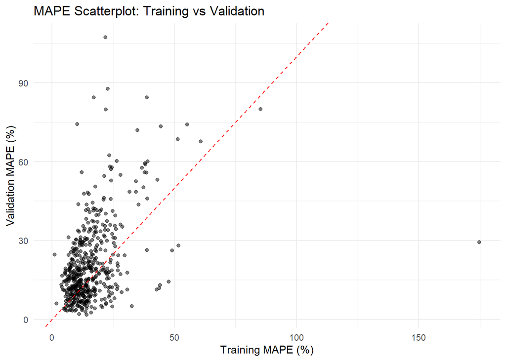

```r
plot_MAPE = ggplot(data_MAPE, aes(x = MAPE.x, y = MAPE.y)) +
  geom_point(alpha = 0.5) +
  geom_abline(intercept = 0, slope = 1, col = "red", linetype = "dashed") +
  labs(title = "MAPE Scatterplot: Training vs Validation", x = "Training MAPE (%)",
       y = "Validation MAPE (%)") +
  theme_minimal()
print(plot_MAPE)
```

In the MAPE scatterplot, most points lie above the red dashed line (bisector of the first and third quadrants) and this means the error in the validation period (last 4 years) is generally higher than in the training period. There seems to be a moderate positive correlation in MAPE which means series that were “hard” to forecast in the past (high Training MAPE) tended to remain “hard” to forecast in the future (high Validation MAPE), though the relationship is noisy.

```r
data_MASE = left_join(MASE_train, MASE_test, by = 'Series')
data_MASE
```

```
## # A tibble: 518 × 7
##    Series .type.x  .model.x MASE.x .type.y .model.y MASE.y
##    <chr>  <chr>    <chr>     <dbl> <chr>   <chr>     <dbl>
##  1 Y1     Training Naive         1 Test    Naive      5.47
##  2 Y10    Training Naive         1 Test    Naive      3.96
##  3 Y100   Training Naive         1 Test    Naive      1.18
##  4 Y101   Training Naive         1 Test    Naive      2.30
##  5 Y102   Training Naive         1 Test    Naive      3.50
##  6 Y103   Training Naive         1 Test    Naive      3.74
##  7 Y104   Training Naive         1 Test    Naive      1.36
##  8 Y105   Training Naive         1 Test    Naive      2.81
##  9 Y106   Training Naive         1 Test    Naive      3.17
## 10 Y107   Training Naive         1 Test    Naive      1.72
## # ℹ 508 more rows
```

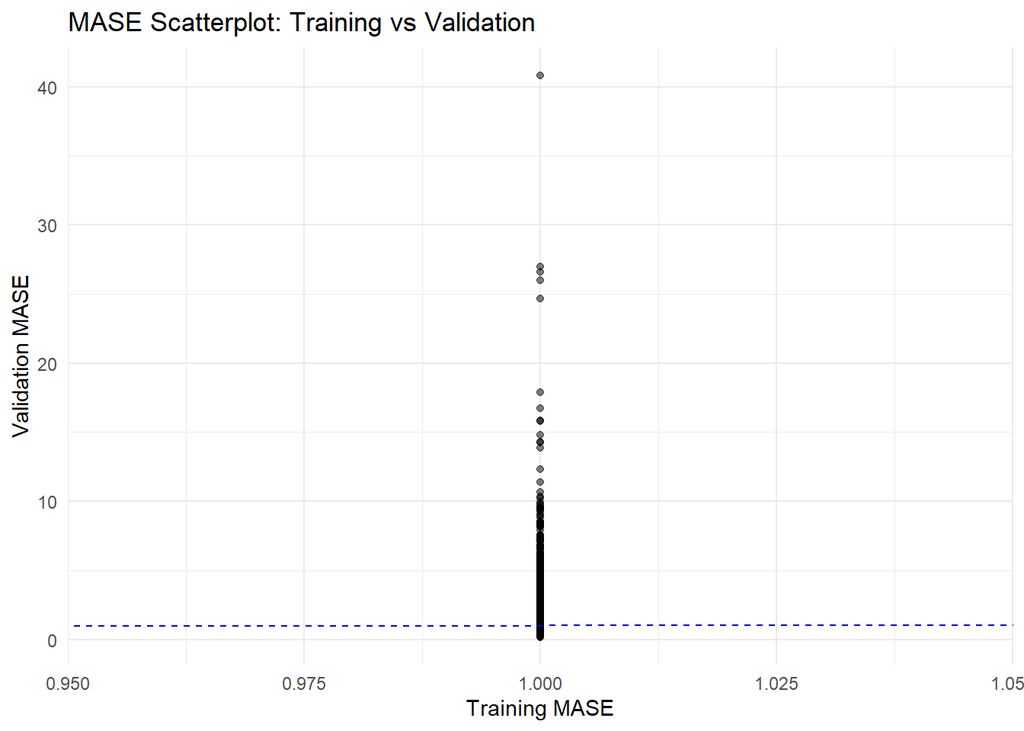

```r
plot_MASE = ggplot(data_MASE, aes(x = MASE.x, y = MASE.y)) +
  geom_point(alpha = 0.5) +
  geom_abline(intercept = 0, slope = 1, col = "blue", linetype = "dashed") +
  labs(title = "MASE Scatterplot: Training vs Validation", x = "Training MASE",
       y = "Validation MASE") +
  theme_minimal()
print(plot_MASE)
```

The MASE scatterplot is a vertical line at x = 1.0 because for a Naive forecast the “Training MASE” is mathematically defined as exactly 1: while the denominator of MASE is the error of the naive method in-sample, the numerator is also the error of the naive method in-sample, thus the ratio is always 1. This tells us that the “Training MASE” is not a useful metric for comparing the variability of series when using the Naive method itself. It only serves as the baseline. Furthermore it seems that the validation period contains more volatility or a structural break compared to training period.

Performance ranges widely across series: there is high variance due to the enormous variation between series. Regarding MAPE scatterplot, some series are very stable (errors < 5%), while others are extremely erratic (errors > 100%). On the other hand, in MASE scatterplot the values range from roughly 0 (series that became much easier to forecast) to over 40 (series that completely broke from their historical pattern and they are harder to forecast).

# 9 Exercise 8

The competition winner, Lee Baker, used an ensemble of three methods:  
- Naive forecasts multiplied by a constant trend (global/local trend: ”globally tourism has grown ”at a rate of 6% annually.”);  
- Linear regression;  
- Exponentially-weighted linear regression.

## 9.1 Letter a

Exact formula used for generating the first method is $F_{t+k} = y_t \times (1.06)^k$ where:  
- $F_{t+k}$ is the forecast for k years ahead;  
- $y_t$ is the last observed value in the training set (the Naive component);  
- $1.06$ represents the 6% annual growth rate mentioned in the text (derived from the domain knowledge that “globally tourism has grown at a rate of 6% annually”);  
- $k$ is the forecast horizon (number of years into the future).

## 9.2 Letter b

While standard Naive forecasting assumes the future will be identical to the last observation ($F_{t+k} = y_t$), this “Naive with Trend” method assumes that the last observation is the baseline, but the series will continue to grow exponentially at a constant global rate of 6% per year. Standard Naive forecasts assume a random walk (today is the best predictor of tomorrow) and this works well for stock prices, which can go up or down with equal probability. However, tourism data often follows a Geometric Random Walk with Drift because tourism is rarely a stationary process. Indeed, over the last several decades, it has been a growth industry and international tourism arrivals have historically grown as global GDP rises and the middle class expands, disposable income for travel increases.

## 9.3 Letter c

The model equation for this data could be $Y_t = \beta_0 + \beta_1 t + \epsilon_t$, where:  
- $Y_t$ is the tourism metric (e.g., inbound tourism numbers) at time $t$;  
- $t$ is the time index and in a univariate setting without external data (like GDP or prices), we use “Time” as a proxy for all the factors that cause tourism to grow over the long term;  
- $\beta_0$ is the intercept to the y-axis (the theoretical baseline level of tourism at time 0);  
- $\beta_1$ is the marginal effect which represents the average annual increase (or decrease) in tourism metric due to one unit increase of the independent variable, keeping fixed all the other variables;  
- $\epsilon_t$ is the error term (residuals). For forecasting purposes, we require that residuals have zero mean and are uncorrelated between them and also with the predictors.

Autoregressive model (AR) could be an alternative solution. In this approach, we can use multiple regression with the past values of the variable to predict the current value: $y_t = \beta_0 + \beta_1 y_{t-1} + \beta_2 y_{t-2} + \dots + \epsilon_t$, where predictors are the lagged values of $y_t$ and the dependent variable is the current tourism demand. Although this method is correct, applying it to our `tourism_data` is risky for two reasons:  
- our data has a strong upward trend in most of the series and AR model often struggle with non-stationary data that grows over time;  
- every time we add a lag, we lose an observation from the start of our training set. It works great for the longer series, but it will fail completely for the shorter series because the creation of lag variables consumes the few data points we have in the training set.

For these reasons the Simple Linear Regression is more robust for short, trended series because it doesn’t require “lagging” (and thus losing) the early data points.

## 9.4 Letter d

```r
# We filter for only the first 5 series on the long tsibble
subset_data = tourism_ts %>%
  filter(Series %in% c("Y1", "Y2", "Y3", "Y4", "Y5"))

# Training set: all data except the last 4 years
train_subset = subset_data %>%
  filter(Time <= max(Time) - 4)

# we fit the Linear Regression Model (TSLM) on training set
fit_subset = train_subset %>%
  model(lm = TSLM(Value ~ Time))
report(fit_subset)
```

```
## # A tibble: 5 × 16
##   Series .model r_squared adj_r_squared  sigma2 statistic  p_value    df log_lik
##   <chr>  <chr>      <dbl>         <dbl>   <dbl>     <dbl>    <dbl> <int>   <dbl>
## 1 Y1     lm         0.921         0.905  5.11e5      58.0 6.21e- 4     2   -54.8
## 2 Y2     lm         0.959         0.957  4.59e8     580.  8.16e-19     2  -307.
## 3 Y3     lm         0.889         0.884  2.68e8     185.  1.77e-12     2  -277.
## 4 Y4     lm         0.749         0.726  2.35e8      32.8 1.33e- 4     2  -143.
## 5 Y5     lm         0.698         0.671  1.62e6      25.5 3.75e- 4     2  -110.
## # ℹ 7 more variables: AIC <dbl>, AICc <dbl>, BIC <dbl>, CV <dbl>,
## #   deviance <dbl>, df.residual <int>, rank <int>
```

```r
# We forecast the next 4 years (validation period)
fc_subset = fit_subset %>%
  forecast(h = 4)
print(fc_subset, width = Inf)
```

```
## # A fable: 20 x 5 [1]
## # Key:     Series, .model [5]
##    Series .model  Time              Value   .mean
##    <chr>  <chr>  <dbl>             <dist>   <dbl>
##  1 Y1     lm        40   N(31399, 876079)  31399.
##  2 Y1     lm        41    N(32428, 1e+06)  32428.
##  3 Y1     lm        42  N(33457, 1241112)  33457.
##  4 Y1     lm        43  N(34486, 1478384)  34486.
##  5 Y2     lm        40 N(360296, 5.3e+08) 360296.
##  6 Y2     lm        41 N(373048, 5.4e+08) 373048.
##  7 Y2     lm        42 N(385801, 5.5e+08) 385801.
##  8 Y2     lm        43  N(4e+05, 5.6e+08) 398553.
##  9 Y3     lm        40 N(185909, 3.1e+08) 185909.
## 10 Y3     lm        41 N(192081, 3.2e+08) 192081.
## 11 Y3     lm        42  N(2e+05, 3.3e+08) 198253.
## 12 Y3     lm        43  N(2e+05, 3.3e+08) 204425.
## 13 Y4     lm        40 N(107665, 3.2e+08) 107665.
## 14 Y4     lm        41 N(114166, 3.4e+08) 114166.
## 15 Y4     lm        42 N(120668, 3.6e+08) 120668.
## 16 Y4     lm        43 N(127169, 3.8e+08) 127169.
## 17 Y5     lm        40  N(15324, 2176187)  15324.
## 18 Y5     lm        41  N(15800, 2309422)  15800.
## 19 Y5     lm        42  N(16275, 2460423)  16275.
## 20 Y5     lm        43  N(16751, 2629189)  16751.
```

```r
# We compare the forecasts against the actual values in the full dataset
accuracy_results = accuracy(fc_subset, subset_data) %>%
  select(Series, .model, .type, RMSE, MAE, MAPE, MASE)
accuracy_results
```

```
## # A tibble: 5 × 7
##   Series .model .type   RMSE    MAE  MAPE  MASE
##   <chr>  <chr>  <chr>  <dbl>  <dbl> <dbl> <dbl>
## 1 Y1     lm     Test   3717.  3448.  9.26  3.06
## 2 Y2     lm     Test  86269. 77982. 22.7   4.23
## 3 Y3     lm     Test  44967. 32723. 24.8   2.69
## 4 Y4     lm     Test  18326. 17577. 18.2   1.91
## 5 Y5     lm     Test  13636.  7341. 18.7   8.75
```

## 9.5 Letter e

Using high-order polynomials (e.g, 5th order) to forecast time series is dangerous because of their behavior outside the training set. Polynomials of order $k > 1$ tend to explode towards $+\infty$ or $-\infty$ very rapidly as you move away from the range of our data (extrapolation). A 5th-order polynomial might wiggle to fit every bump perfectly. However, for the next 4 years (forecast horizon), the curve might shoot vertically upwards or crash to negative values, producing absurd forecasts due to overfitting. This phenomenon often occurs with too complex models or insufficient datasets, performing excellently on training data but poorly at making predictions on novel data, leading to poor generalization ability and making the model unreliable.

Using $R^2$ for blending the results essentially rewards overfitting. In trended time series, $R^2$ is often artificially high (e.g., $R^2$ > 0.90) simply because there is a trend and it doesn’t punish autocorrelation in the residuals. A model can have $R^2 = 0.99$ and still produce biased, poor forecasts because it ignores the serial dependence of the errors. Relying on it for blending the results of the prediction, gives a false sense of confidence in the model.

## 9.6 Letter f

If we were to consider exponential smoothing, the types that are reasonable candidates:  
- Holt’s linear trend (A, A, N);  
- Damped trend method (A, Ad, N);  
- previous models with multiplicative error that are ETS(M, A, N) and ETS(M, Ad, N).

## 9.7 Letter g

Feature-based FORecast Model Averaging (FFORMA), developed by Monash University researchers, is a really effective approach which leads to easier automation of the ensemble step. We start with extracting features for every time series, calculating the main characteristics(e.g., using feasts in R). Then, we need to use a machine learning model like XGBoost that builds decision trees sequentially, where each tree corrects the errors of the previous one. This focuses heavily on reducing bias and it can directly optimize complex custom loss functions (like the forecasting error minimization). The inputs are the features of the series, while the outputs are the optimal weights for the base models. The meta-learner adapts to each specific series automatically and we have 518 custom ensembles generated by the algorithm.  
Also we could use another machine learning model like Random Forest that leverages two forms of randomness to achieve low variance and low bias; it is based on bootstrap aggregating (bagging) to improve the accuracy of individual trees, and on random input selection during node splitting to further enhance diversity.

## 9.8 Letter h

In a real-life tourism forecasting scenario we may have different weighting because high-volume/high-value series should matter more than other series. The cost of erratic forecasting is higher, thus under-forecasting might mean lost revenue (opportunity costs), while over-forecasting might mean wasted budget.The competition focused on minimizing the average MAPE of the next four values across all 518 series, while in a real-life tourism forecasting scenario MAE or RMSE are often useful because they are scale dependent and consider the physical number of people (e.g., seats on planes, visitor nights or inbound tourism number to one country from another country) that matters more than the percentage.  
In the forecasting process the steps that would likely be different:  
- building a hierarchy where we could forecast “Total Country” first, then break it down by Region, then by City; we would ensure that the sum of the regional forecasts equals the national forecast. This ensures consistency for decision-makers at different levels;  
- including explanatory variables that affect tourism such as GDP of origin countries, exchange rates, marketing spend or special events organized in the country;  
- preferring a simpler and more interpretable model (like Simple Linear Regression) because stakeholders need to understand why the forecast is going up or down.